# Deep Learning with Convnets: Computer Vision

Introduction  
Step 1: Defining the problem and assembling a dataset  
Step 2: Choosing a measure of success  
Step 3: Deciding on an evaluation protocol  
Methodology  
Step 4: Preparing the data  
Step 5: Develop a model that does better than a baseline  
Step 6: Develop a model that overfits  
Step 7: Regularizing the model  
Results  
Conclusion

# Introduction

This report is based on the text Deep Learning with Python by François Chollet (hereon referred to as DLWP). Specifically, it is largely based on chapter 4.5 of the first edition and chapter 8 of the second edition.

## Step 1: Defining the problem and assembling a dataset

Given an input of an image that contains either one cat or one dog, we wish to predict the species of the depicted animal. As such, we are dealing with a binary classification task. As a dataset, we can use Kaggle's "Dogs vs Cats" dataset from 2013.

### Downloading the dataset

If you intend to run any of the code in this Jupyter notebook, you must first create a [Kaggle](https://www.kaggle.com) account if you do not already have one, go to your account settings, and then click "Create API Key" and save the JSON file to `$HOME/.kaggle/kaggle.json`. You must then go to [this page](https://www.kaggle.com/c/dogs-vs-cats/rules) and click "I Understand and Accept" (you may need to verify your account first if asked to). This will enable you to download the dataset via the Kaggle API as follows.

```python
!kaggle competitions download -c dogs-vs-cats
!unzip -qq dogs-vs-cats.zip
!unzip -qq train.zip
```

The images are of varying quality but all of them contain a cat or dog that is clearly discernable to a human viewer. Other objects may be present in the images, such as a human arm as seen here in this somewhat blurry image that appears to have been captured with a mobile phone camera:

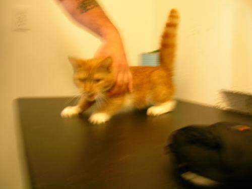

```python
from IPython.display import Image
Image(filename="train/cat.0.jpg")
```

Nevertheless, we can hypothesize that the quality of these inputs are sufficiently informative to map inputs to predictive outputs.

We can moreover note that this is a stationary problem, in that the general appearances of cats and dogs is not something that will change with any practical length of time that concerns us. We therefore do not need to worry about updating and retraining our model, as would likely be needed in the case of something like fashion trends.

## Step 2: Choosing a measure of success

Since this is a binary classification problem with a symmetric dataset (50% cats and 50% dogs), we can use accuracy as a measure of success. A baseline classifier that outputs a random guess for each image would achieve 50% accuracy on average. We must therefore aim to beat 50% accuracy.

## Step 3: Deciding on an evaluation protocol

The dataset we intend to work with will contain 25000 images which is quite a lot. Convnets can be quite effective with datasets that are smaller than this. Hold-out validation should therefore be an appropriate choice for evaluation. We might choose K-fold cross-validation or iterated K-fold validation if we were dealing with a smaller dataset.

# Methodology

## Step 4: Preparing the data

The original dataset contains 25000 training images and 12500 test images, with the training set having an even split between cat and dog images. However, the test images are unlabelled so we will be ignoring them and will instead split the training set into training (60%), validation (20%), and test (20%) sets. The image names are in the format `[SPECIES].[ID].jpg` where [SPECIES] is either `cat` or `dog` and [ID] is in the range [0, 12500).

The following code has been taken from DLWP and slightly modified. It splits the training set into training, validation and test set directories, and moreover creates separate directories for cats and dogs within each parent set directory.

```python
import os, shutil, pathlib

original_dir = pathlib.Path("train")
new_base_dir = pathlib.Path("cats_vs_dogs")

def make_subset(subset_name, start_index, end_index):
    for category in ("cat", "dog"):
        dir = new_base_dir / subset_name / category
        if not os.path.isdir(dir):
            os.makedirs(dir)
        fnames = [f"{category}.{i}.jpg" for i in range(start_index, end_index)]
        for fname in fnames:
            shutil.copyfile(src=original_dir / fname,
                            dst=dir / fname)

make_subset("train", start_index=0, end_index=7500)
make_subset("validation", start_index=7500, end_index=10000)
make_subset("test", start_index=10000, end_index=12500)
```

This produces a training set of 15000 images (7500 cats and 7500 dogs), a validation set of 5000 images (2500 cats and 2500 dogs), and a test set of 5000 images (2500 cats and 2500 dogs).

Machine learning models expect as input homogeneous tensors of floating-point numbers within a small range. As such, we will need to resize all the images. For this will we choose 180x180 pixels. Additionally, the RGB values should be scaled to the range [0, 1], and the images should be put into batches so that we do not need to load all of them into memory. All of this can conveniently be done via Keras' `image_dataset_from_directory` function which will also shuffle the data. DLWP demonstrates that this can be done as follows:

```python
from tensorflow.keras.preprocessing import image_dataset_from_directory

train_dataset = image_dataset_from_directory(
    new_base_dir / "train",
    image_size=(180, 180),
    batch_size=32
)
validation_dataset = image_dataset_from_directory(
    new_base_dir / "validation",
    image_size=(180, 180),
    batch_size=32
)
test_dataset = image_dataset_from_directory(
    new_base_dir / "test",
    image_size=(180, 180),
    batch_size=32
)
```

```
Found 15000 files belonging to 2 classes.
Found 5000 files belonging to 2 classes.
Found 5000 files belonging to 2 classes.
```

## Step 5: Develop a model that does better than a baseline

As previously mentioned, our baseline is an accuracy of 50% which our model must exceed. For the intermediate layers of the model, we will be relying on convnets which are widely used in computer vision.

### Use of convnets

A convnet is essentially a stack of `Conv2D` and `MaxPooling2D` layers whose input tensors are of shape ([IMAGE HEIGHT], [IMAGE WIDTH], [IMAGE CHANNELS]). Where as `Dense` layers are limited to learning patterns in their global input space (i.e. all pixels of an image), convnets can learn local patterns (i.e. patterns within an image). These patterns can then be recognised wherever they appear. Additionally, subsequent layers can learn patterns based on features of previous layers. Convnets therefore require fewer samples to achieve generalisation power.

The convolution operation (`Conv2D`) takes as input a 3D tensor and outputs another 3D tensor by applying transformations to patches within the input's subspace. The job of the max-pooling operation (`MaxPooling2D`) is then to aggressively downsample these 3D tensors with the goal of reducing the number of parameters to process.

The following function is based on code from DLWP and creates our model using intermediate convnet layers. An initial layer scales the inputs from range [0, 255] to range [0, 1]. For binary classifiers, a standard practice is to use `sigmoid` for last layer activation which is what is being done here.

```python
from tensorflow import keras
from tensorflow.keras import layers

def create_model(num_layers=1, dropout=None, regularizer=None):
    inputs = keras.Input(shape=(180, 180, 3))
    x = layers.experimental.preprocessing.Rescaling(1 / 255)(inputs)
    # add successively larger intermediate convnet layers
    for i in range(num_layers):
        conv_filters = 2 ** (5 + i)
        x = layers.Conv2D(
            filters=conv_filters, kernel_size=3, activation="relu", kernel_regularizer=regularizer
        )(x)
        x = layers.MaxPooling2D(pool_size=2)(x)
    conv_filters = 2 ** (4 + num_layers)
    x = layers.Conv2D(
        filters=conv_filters, kernel_size=3, activation="relu", kernel_regularizer=regularizer
    )(x)
    x = layers.Flatten()(x)
    if dropout:
        x = layers.Dropout(dropout)(x)
    # last layer activation
    outputs = layers.Dense(1, activation="sigmoid")(x)
    model = keras.Model(inputs=inputs, outputs=outputs)
    # compilation
    model.compile(
        loss="binary_crossentropy",
        optimizer="rmsprop",
        metrics=["accuracy"]
    )
    return model
```

It is also standard practice to use `binary_crossentropy` for the loss function of a binary classifier. For the optimizer, DLWP mentions that "in most cases, it's safe to go with `rmrprop` and its default learning rate", so we will be using that. Now to compile the model with the appropriate settings. Let's also take a look at the model's summary.

```python
model = create_model()
model.summary()
```

```
Model: "model_5"
_________________________________________________________________
Layer (type)                 Output Shape              Param #
=================================================================
input_6 (InputLayer)         [(None, 180, 180, 3)]     0
_________________________________________________________________
rescaling_5 (Rescaling)      (None, 180, 180, 3)       0
_________________________________________________________________
conv2d_18 (Conv2D)           (None, 178, 178, 32)      896
_________________________________________________________________
max_pooling2d_14 (MaxPooling (None, 89, 89, 32)        0
_________________________________________________________________
conv2d_19 (Conv2D)           (None, 87, 87, 32)        9248
_________________________________________________________________
flatten_5 (Flatten)          (None, 242208)            0
_________________________________________________________________
dense_5 (Dense)              (None, 1)                 242209
=================================================================
Total params: 252,353
Trainable params: 252,353
Non-trainable params: 0
_________________________________________________________________
```

We can also define a training function below. Again, this is based on code from DLWP and uses Keras callbacks to save and monitor the state of the training.

```python
def train_model(model, epochs=10):
    callbacks = [
        keras.callbacks.ModelCheckpoint(
            filepath="convnet_from_scratch.keras",
            save_best_only=True,
            monitor="val_loss"
        )
    ]
    history = model.fit(
        train_dataset,
        epochs=epochs,
        validation_data=validation_dataset,
        callbacks=callbacks
    )
    return callbacks, history
```

Let us now train the preliminary model.

```python
callbacks, history = train_model(model)
```

Let's now define a function to plot some graphs comparing training and validation accuracies and losses per epoch. The code within this function has been taken directly from DLWP.

```python
import matplotlib.pyplot as plt

def plot_results(history):
    accuracy = history.history["accuracy"]
    val_accuracy = history.history["val_accuracy"]
    loss = history.history["loss"]
    val_loss = history.history["val_loss"]
    epochs = range(1, len(accuracy) + 1)
    plt.plot(epochs, accuracy, "bo", label="Training accuracy")
    plt.plot(epochs, val_accuracy, "b", label="Validation accuracy")
    plt.title("Training and validation accuracy")
    plt.legend()
    plt.figure()
    plt.plot(epochs, loss, "bo", label="Training loss")
    plt.plot(epochs, val_loss, "b", label="Validation loss")
    plt.title("Training and validation loss")
    plt.legend()
    plt.show()
```

Let's see what the graphs look like.

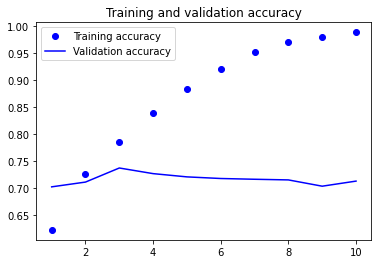

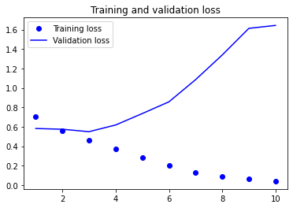

```python
plot_results(history)
```

Notice that the validation loss continuously increases after the third epoch. This indicates that the third epoch is the optimal epoch for the current model. We can confirm this by defining a function to return the epoch at which the validation loss is lowest.

```python
def get_optimal_epoch(history):
    val_loss = history.history["val_loss"]
    return val_loss.index(min(val_loss)) + 1
```

```python
get_optimal_epoch(history)
```

```
3
```

Let's now test the model. Keras' `load_model` will load the best-fit model (i.e. the one trained using the optimal number of epochs) from the saved callback checkpoints. Based on the examples from DLWP we can define a `test_model` function and run it.

```python
def test_model(filename, test_dataset):
    model = keras.models.load_model(filename)
    test_loss, test_acc = model.evaluate(test_dataset)
    print(f"Test accuracy: {test_acc:.3f}")
```

```python
test_model("convnet_from_scratch.keras", test_dataset)
```

```
Test accuracy: 0.742
```

The model has a test accuracy of 74.2%, better than our common sense baseline of 50%. We have thus achieved statistical power, but further improvements can be made.